# Repeatable Workflows for Text Mining in Higher Education

Jill MacKay

2021-03-12

# About

This file accompanies MacKay 2021 “Freeing the Free Text Comment”. It shows a reproducible and share-able workflow for text mining where the data itself may be too sensitive to share. The sample data I am using is [Palmer & Herbert’s The Teacher](http://www.gutenberg.org/ebooks/36774). (Although you can utilise this process on any text, you can follow the instructions here on how to get this specific text).

# Setting up your R Environment

This workflow uses the following packages and user-defined functions.

```r
library(tidytext)
library(tidyverse)
library(textstem)
```

This function allows for quick calculation of Term Frequency - Inverse Document Frequency

```r
lazytf <- function (data, word = "word", grouping_factor) {
  qgv <- enquo (grouping_factor)
  word <- enquo (word)
  data %>%
    group_by(!!qgv) %>%
    count (!!qgv, !!word, sort = TRUE) %>%
    ungroup() %>%
    mutate (total = sum(n)) %>%
    bind_tf_idf (., !!word, !!qgv, n)

}
```

# Documenting data files

Our current data frame is a data frame currently called `rawtext`. The data frame has two columns:

- `collection` - which essay collection did the row come from
- `text` - the full text of the essay

The data frame has three rows of data, one for each collection.

This data therefore follows tidy data principles, in that each row is an observation, and each column is a variable.

We can process this using the `tidytext` package.

The following code fully describes (in an automated fashion) how the data is processed ready for text mining.

```r
# Create a lexicon of words which should not be considered
# And append this custom lexicon to the standard 'stop_words' lexicon

my_stops <- tibble(word = c("gutenberg", "project"),
                   lexicon = c("my_stops", "my_stops"))
my_stops <- full_join(stop_words, my_stops)


# Tokenise the text
# Run a lemmatisation protocol
# Remove common words based on custom lexicon
# Remove any remaining words which are only symbols

freetext <- rawtext %>%
  unnest_tokens(word, text) %>%
  mutate (lemma = (lemmatize_strings(word))) %>%
  anti_join(my_stops) %>%
  filter(str_detect(lemma, '[^0-9]'))
```

# Documenting all operations

## What words are used most frequently?

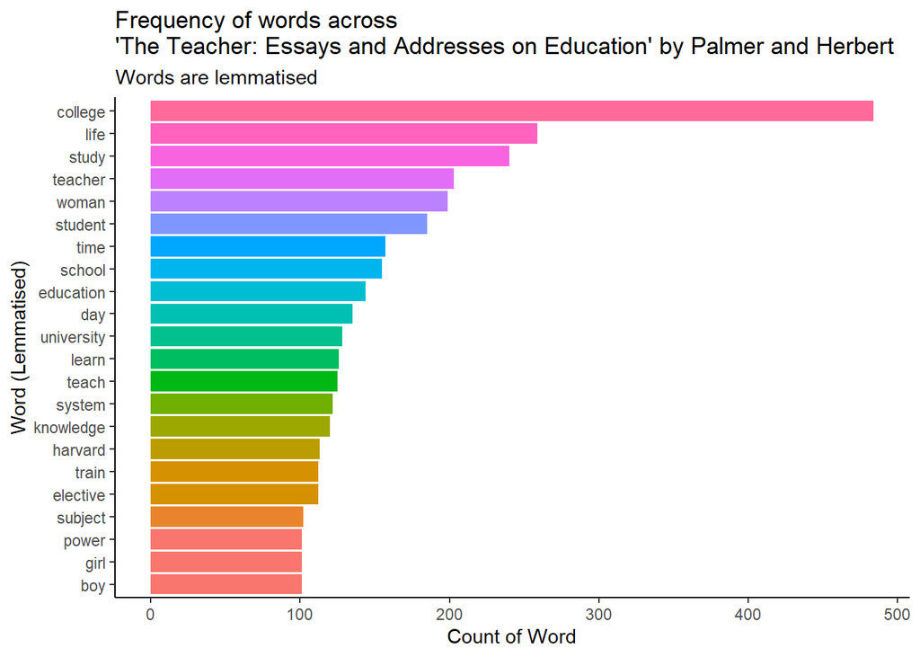

```r
freetext %>%
  count(lemma, sort = T) %>%
  top_n(20) %>%
  ggplot(aes(x = reorder(lemma,n), y = n, fill = as.factor(n))) +
  geom_bar(stat = "identity") +
  theme_classic() +
  coord_flip() +
  labs(y = "Count of Word", x = "Word (Lemmatised)",
       title = "Frequency of words across\n'The Teacher: Essays and Addresses on Education' by Palmer and Herbert",
       subtitle = "Words are lemmatised") +
  theme(legend.position = "none")
```

## What words are used most frequently within each collection?

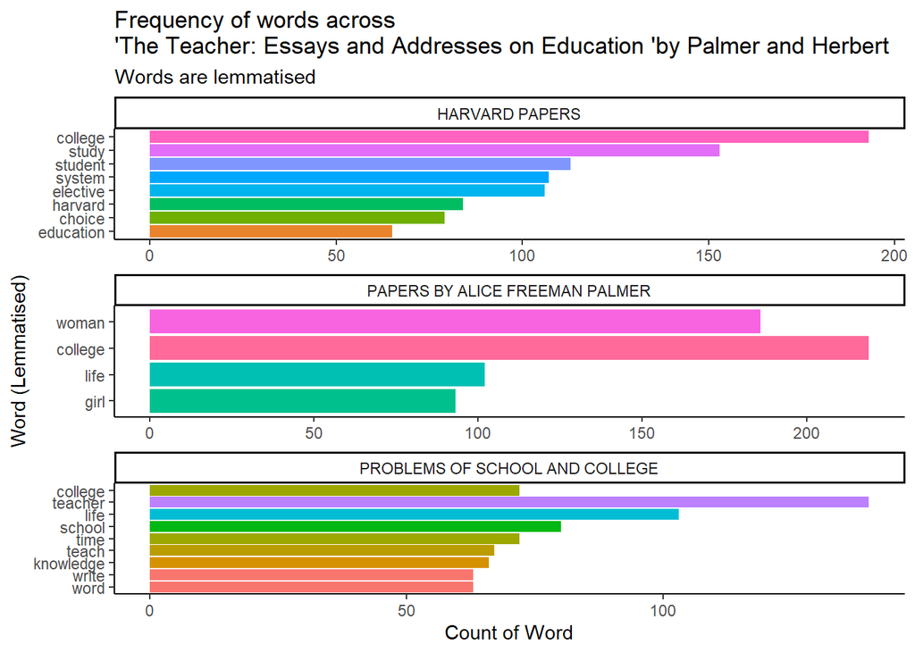

```r
freetext %>%
  count(collection, lemma, sort = T) %>%
  top_n(20) %>%
  ggplot(aes(x = reorder(lemma,n), y = n, fill = as.factor(n))) +
  geom_bar(stat = "identity") +
  theme_classic() +
  coord_flip() +
  facet_wrap(facets = ~ collection, scales = "free", nrow = 3) +
  labs(y = "Count of Word", x = "Word (Lemmatised)",
       title = "Frequency of words across\n'The Teacher: Essays and Addresses on Education 'by Palmer and Herbert",
       subtitle = "Words are lemmatised") +
  theme(legend.position = "none")
```

## Are some words more unique in certain collections?

### Calculating Term Frequency - Inverse Document Frequency (TF-IDF)

```r
# Create a new dataframe containing tf-idf

freetf <- lazytf(freetext, word = lemma, grouping_factor = collection)
```

### Visualising TF-IDF

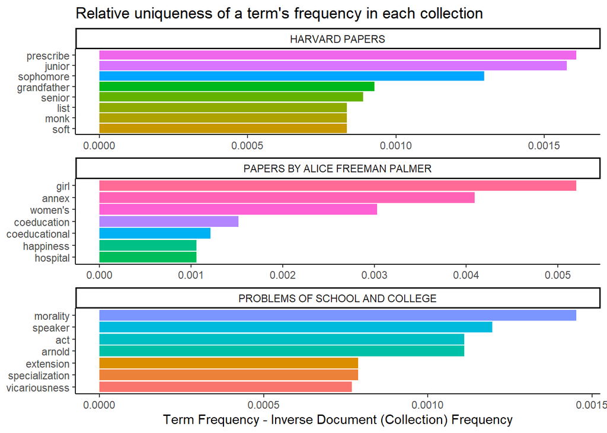

```r
freetf %>%
  arrange(desc (tf_idf)) %>%
  mutate (lemma = factor (lemma, levels = rev(unique(lemma)))) %>%
  group_by (collection) %>%
  top_n(7, tf_idf) %>%
  ungroup()  %>%
  ggplot(aes(lemma, tf_idf, fill = lemma)) +
  geom_col(show.legend = FALSE) +
  labs (x = NULL, y = "Term Frequency - Inverse Document (Collection) Frequency",
        title = "Relative uniqueness of a term's frequency in each collection") +
  facet_wrap(~collection, nrow = 3, scales = "free") +
  theme_classic() +
  coord_flip()
```

## Are there differences in sentiment across the collections?

What words contribute the most to overall sentiment (using the Bing sentiment lexicon)?

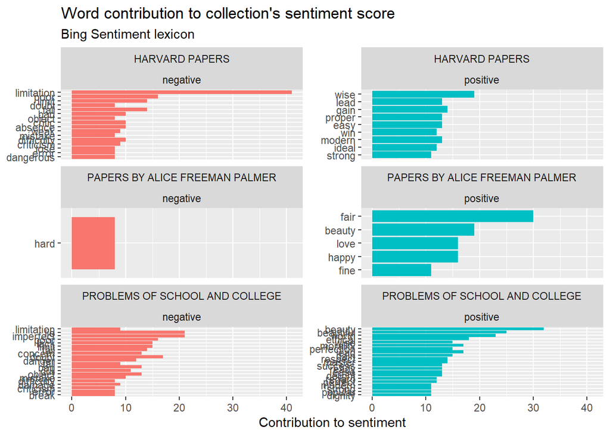

```r
freetext %>%
  inner_join(get_sentiments("bing")) %>%
  count(collection, lemma, sentiment, sort = TRUE) %>%
  ungroup() %>%
  group_by(sentiment) %>%
  top_n(30) %>%
  ungroup() %>%
  mutate(lemma = reorder(lemma, n)) %>%
  ggplot(aes(n, lemma, fill = sentiment)) +
  geom_col(show.legend = FALSE) +
  facet_wrap(~collection + sentiment, scales = "free_y", nrow = 3) +
  labs(x = "Contribution to sentiment",
       y = NULL,
       title = "Word contribution to collection's sentiment score",
       subtitle = "Bing Sentiment lexicon")
```

Do the collections show similar sentiment progression?

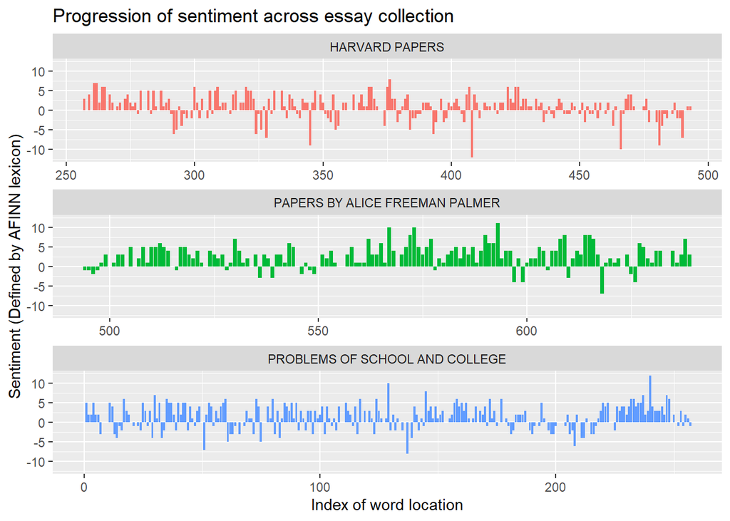

```r
freetext %>%
  mutate(location = row_number(),
         word = lemma) %>%
  inner_join(get_sentiments("afinn")) %>%
  mutate(sentiment = case_when(value <0 ~ "negative",
                               value >0 ~ "positive")) %>%
  count(collection, index = location %/% 50, sentiment) %>%
  spread(sentiment, n, fill = 0) %>%
  mutate(sentiment = positive - negative) %>%
  ggplot(aes(index, sentiment, fill = collection)) +
  geom_col(show.legend = FALSE) +
  facet_wrap(~collection, ncol = 1, scales = "free_x") +
  labs(x = "Index of word location",
       y = "Sentiment (Defined by AFINN lexicon)",
       title = "Progression of sentiment across essay collection")
```